# Metformin XR BE Safe Space — IR High-Variability Sensitivity (PBPK)

Reference T50 = 3.0 h · within-subject CV = immediate-release (Cmax 23.7%, AUC 14.7%)

Author

Nikita

Published

June 9, 2026

## Purpose

This is a **sensitivity companion** to the main report (`be_safe_space_report.html`). It repeats the virtual-bioequivalence (VBE) safe-space analysis — same PBPK population, same 3.0 h reference, same 500 trials at n = 48 and 86 — but substitutes the **higher within-subject variability of metformin IMMEDIATE-release** for the extended-release values. The question: *how much does the safe space shrink if the product behaved like a higher-variability formulation?*

Metformin is a low-variability drug, but reported intra-subject CVs span a range. The IR / upper-bound values used here bracket that range:

Table 1: Within-subject CV scenarios. This report uses the IR / high-variability row. {#tbl-cv}

| Scenario | Cmax intra-CV | AUC intra-CV | Basis |
| --- | --- | --- | --- |
| Main report — ER (FDA NDA 212595) | 12.2% | 11.2% | metformin extended-release |
| This report — IR / high (sensitivity bound) | 23.7% | 14.7% | metformin IR tablets (22.7–25.7%, obs. 24.8%); AUC pooled 14.7% |

> The point average-BE estimates (GMR and 90% CI) are **unchanged** from the main report — they are deterministic and do not depend on the assumed within-subject CV. Only the VBE *power* (and hence the safe-space width) changes. See the main report for the BE table.

## Safe space by endpoint (IR variability; 500 trials; n = 48 and 86)

Green = safe space (power ≥ 80%), red = fail; open circles = the 8 simulated formulations; a tick marks every simulated T50.

### C<sub>max</sub> (BE-determining endpoint)

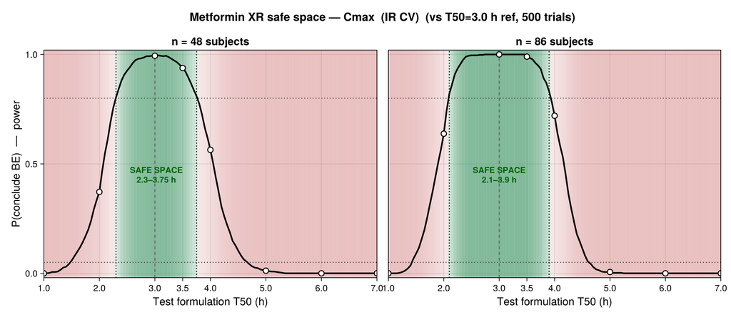

Figure 1: IR-variability safe space for C<sub>max</sub>, n = 48 (left) and n = 86 (right).

**Inference.** Under IR variability the C<sub>max</sub> safe space narrows sharply to **2.30–3.75 h** (n=48) / **2.10–3.90 h** (n=86) — versus 2.00–4.15 / 1.80–4.25 h under ER. Higher trial noise widens the 90% CI, so formulations farther from the reference can no longer pass reliably.

### AUC<sub>0-t</sub>

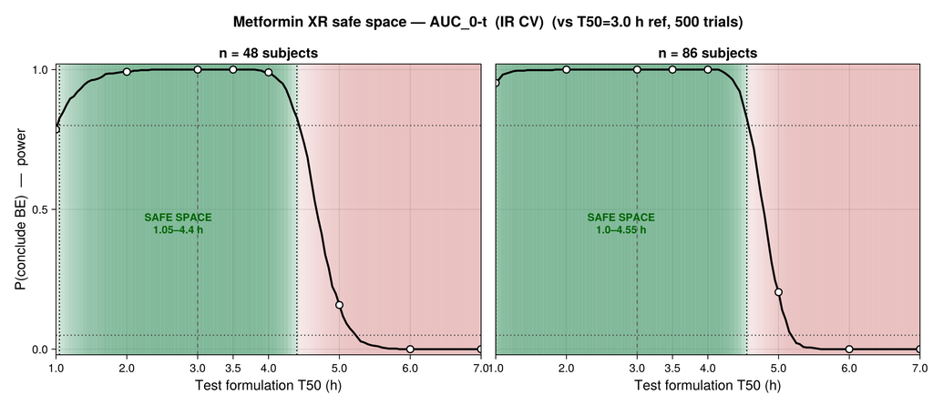

Figure 2: IR-variability safe space for AUC₀-t.

**Inference.** AUC<sub>0-t</sub> stays comparatively wide (~1.0–4.4/4.55 h): its lower assumed CV (14.7%) and smaller true exposure change with release rate keep power high except at the slow extreme. It does not limit the joint decision.

### AUC<sub>∞</sub>

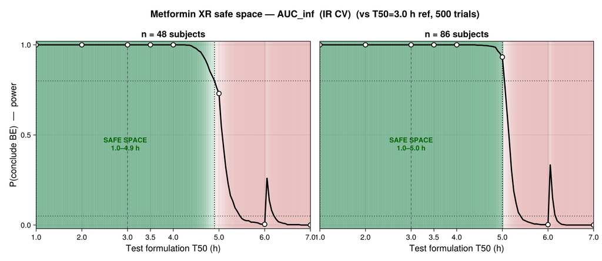

Figure 3: IR-variability safe space for AUC∞.

**Inference.** As in the main report, AUC<sub>∞</sub> is **not reliable** for the slow arms (extrapolation artefact) and should not drive the XR safe space.

### Joint decision (C<sub>max</sub> & AUC<sub>0-t</sub>)

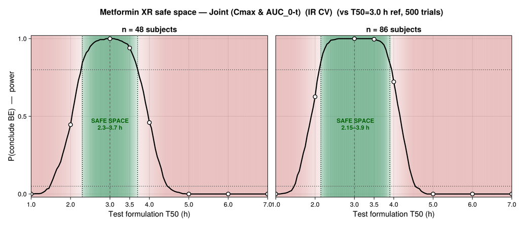

Figure 4: IR-variability safe space for the joint BE decision.

**Inference.** The regulatory (joint) safe space contracts to **≈ 2.30–3.70 h (n=48)** / **2.15–3.90 h (n=86)**, again governed by C<sub>max</sub>.

| Endpoint | IR CV · n=48 | IR CV · n=86 |
| --- | --- | --- |
| Cmax | 2.30–3.75 h | 2.10–3.90 h |
| AUC_inf | 1.00–4.90 h | 1.00–5.00 h |
| AUC_0-t | 1.05–4.40 h | 1.00–4.55 h |
| Joint (Cmax & AUC_0-t) | 2.30–3.70 h | 2.15–3.90 h |

Table 3: VBE pass-rate under IR variability (500 trials). POWER inside the safe space; TYPE I error where the true GMR is outside 80–125% (target ≤ 5%). {#tbl-powerir}

| Test T50 (h) | Cmax n48 | Cmax n86 | AUC_tEnd n48 | AUC_tEnd n86 | AUC_inf n48 | AUC_inf n86 |
| --- | --- | --- | --- | --- | --- | --- |
| 1.0 | 0.0% | 0.0% | 78.6% | 95.2% | 100.0% | 100.0% |
| 2.0 | 37.2% | 63.8% | 99.2% | 100.0% | 100.0% | 100.0% |
| 3.5 | 93.8% | 99.0% | 100.0% | 100.0% | 100.0% | 100.0% |
| 4.0 | 56.4% | 72.0% | 99.0% | 100.0% | 100.0% | 100.0% |
| 5.0 | 1.2% | 0.6% | 15.8% | 20.4% | 73.0% | 93.2% |
| 6.0 | 0.0% | 0.0% | 0.0% | 0.0% | 0.4% | 0.2% |
| 7.0 | 0.0% | 0.0% | 0.0% | 0.0% | 0.0% | 0.0% |

**Inference.** Type I error remains controlled (≤ 5%) at the truly non-equivalent slow arms even under higher variability. The cost of higher CV is **lost power near the edges**, which is what contracts the safe space — not an increase in false-positive BE.